# Introduction

## Corrélation entre le taux de suicide et le nombre d'habitants du pays

```python
import matplotlib
import matplotlib.pyplot as plt
import pandas as pd
```

```python
dfIh = pd.read_csv('./Data/inhabitants.csv', sep=',')
dfBS = pd.read_csv('./Data/Both_sexes_10-29.csv', sep=',')
# il s'agit d'un tableau avec le nombre d'habitant par pays
# on va fusionner ce tableau avec les autres obtenus précédemment
```

```python
print(dfIh.head())
print(dfIh.shape)
print(dfBS.head())
print(dfBS.shape)
```

```
       Country        2016
0        Aruba    104872.0
1  Afghanistan  35383128.0
2       Angola  28842484.0
3      Albania   2876101.0
4      Andorra     77297.0
(264, 2)
   Unnamed: 0              Country  10-14 years  15-19 years  20-24 years  \
0           0          Afghanistan          0.7          5.8         10.7
1           1              Albania          1.5          7.6          6.6
2           2              Algeria          0.4          2.2          3.7
3           3               Angola          0.9          4.7          7.1
4           4  Antigua and Barbuda          0.0          0.0          0.0

   25-29 years
0          9.5
1          6.3
2          4.6
3          6.0
4          0.0
(183, 6)
```

```python
dfBS = dfBS.merge(dfIh, left_on = 'Country', right_on ='Country')
dfBS = dfBS.drop('Unnamed: 0', axis = 1).drop('Country', axis = 1)
dfBS.rename(columns={'2016': 'Nb inhabitant'}, inplace=True)
```

```python
dfBS = dfBS.sort_values(by = 'Nb inhabitant')
dfBS.describe()
```

|  | 10-14 years | 15-19 years | 20-24 years | 25-29 years | Nb inhabitant |
| --- | --- | --- | --- | --- | --- |
| count | 159.000000 | 159.000000 | 159.000000 | 159.000000 | 1.580000e+02 |
| mean | 1.249057 | 6.937107 | 10.367296 | 10.606289 | 4.242686e+07 |
| std | 1.150392 | 5.263831 | 7.199978 | 7.257765 | 1.562386e+08 |
| min | 0.000000 | 0.000000 | 0.000000 | 0.000000 | 9.452700e+04 |
| 25% | 0.400000 | 3.200000 | 5.000000 | 5.400000 | 2.707838e+06 |
| 50% | 0.900000 | 5.300000 | 8.000000 | 8.300000 | 9.431257e+06 |
| 75% | 1.750000 | 8.900000 | 13.600000 | 14.000000 | 2.768774e+07 |
| max | 7.100000 | 28.900000 | 42.000000 | 38.400000 | 1.378665e+09 |

```python
dfBS.to_csv('Both_sexes_10-29_inhabitant.csv')
```

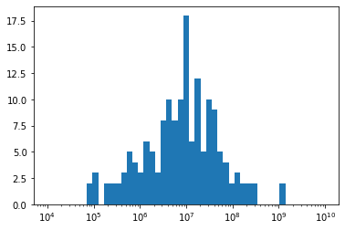

```python
import pylab as pl
import numpy as np
pl.hist(dfBS['Nb inhabitant'], bins=np.logspace(np.log10(1e+4),np.log10(1e+10),50));
pl.gca().set_xscale("log")

plt.savefig('NB1_2_0.png')
```

Avec cet histogramme logarithmique, on justifie la nécessité d'exclure les pays présentant moins de 5e+5 habitants Ceux-ci sont en effet marginaux et présentent des valeurs pouvant être aberrantes Cela représente la suppression de 14 pays, sur environ 160. Nous conservons donc 144 pays.

```python
dfBS = dfBS[dfBS['Nb inhabitant'] >= 5e+5]
print(dfBS.shape)
```

```
(144, 5)
```

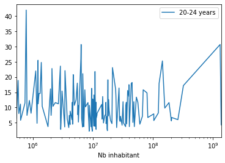

```python
dfBS.plot(x = 'Nb inhabitant',y ='20-24 years', logx = True);
plt.savefig('NB1_2_1.png')
```

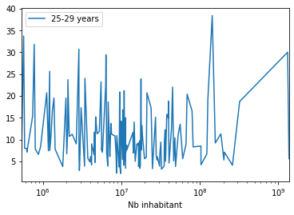

```python
dfBS.plot(x = 'Nb inhabitant',y ='25-29 years', logx = True);
plt.savefig('NB1_2_2.png')
```

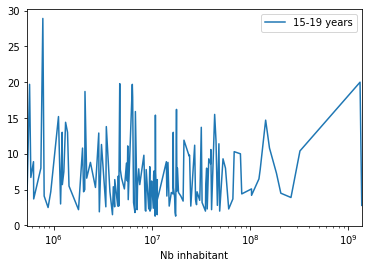

```python
dfBS.plot(x = 'Nb inhabitant',y ='15-19 years', logx = True);
plt.savefig('NB1_2_3.png')
```

## Corrélation entre le taux de suicide et le nombre d'habitants du pays

```python
import matplotlib
import matplotlib.pyplot as plt
import pandas as pd
```

```python
dfIh = pd.read_csv('./Data/inhabitants.csv', sep=',')
dfBS = pd.read_csv('./Data/Both_sexes_10-29.csv', sep=',')
# il s'agit d'un tableau avec le nombre d'habitant par pays
# on va fusionner ce tableau avec les autres obtenus précédemment
```

```python
print(dfIh.head())
print(dfIh.shape)
print(dfBS.head())
print(dfBS.shape)
```

```
       Country        2016
0        Aruba    104872.0
1  Afghanistan  35383128.0
2       Angola  28842484.0
3      Albania   2876101.0
4      Andorra     77297.0
(264, 2)
   Unnamed: 0              Country  10-14 years  15-19 years  20-24 years  \
0           0          Afghanistan          0.7          5.8         10.7
1           1              Albania          1.5          7.6          6.6
2           2              Algeria          0.4          2.2          3.7
3           3               Angola          0.9          4.7          7.1
4           4  Antigua and Barbuda          0.0          0.0          0.0

   25-29 years
0          9.5
1          6.3
2          4.6
3          6.0
4          0.0
(183, 6)
```

```python
dfBS = dfBS.merge(dfIh, left_on = 'Country', right_on ='Country')
dfBS = dfBS.drop('Unnamed: 0', axis = 1).drop('Country', axis = 1)
dfBS.rename(columns={'2016': 'Nb inhabitant'}, inplace=True)
```

```python
dfBS = dfBS.sort_values(by = 'Nb inhabitant')
dfBS.describe()
```

|  | 10-14 years | 15-19 years | 20-24 years | 25-29 years | Nb inhabitant |
| --- | --- | --- | --- | --- | --- |
| count | 159.000000 | 159.000000 | 159.000000 | 159.000000 | 1.580000e+02 |
| mean | 1.249057 | 6.937107 | 10.367296 | 10.606289 | 4.242686e+07 |
| std | 1.150392 | 5.263831 | 7.199978 | 7.257765 | 1.562386e+08 |
| min | 0.000000 | 0.000000 | 0.000000 | 0.000000 | 9.452700e+04 |
| 25% | 0.400000 | 3.200000 | 5.000000 | 5.400000 | 2.707838e+06 |
| 50% | 0.900000 | 5.300000 | 8.000000 | 8.300000 | 9.431257e+06 |
| 75% | 1.750000 | 8.900000 | 13.600000 | 14.000000 | 2.768774e+07 |
| max | 7.100000 | 28.900000 | 42.000000 | 38.400000 | 1.378665e+09 |

```python
dfBS.to_csv('Both_sexes_10-29_inhabitant.csv')
```

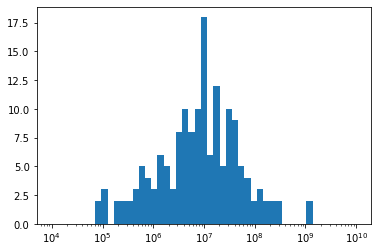

```python
import pylab as pl
import numpy as np
pl.hist(dfBS['Nb inhabitant'], bins=np.logspace(np.log10(1e+4),np.log10(1e+10),50));
pl.gca().set_xscale("log")

plt.savefig('NB1_2_0.png')
```

Avec cet histogramme logarithmique, on justifie la nécessité d'exclure les pays présentant moins de 5e+5 habitants Ceux-ci sont en effet marginaux et présentent des valeurs pouvant être aberrantes Cela représente la suppression de 14 pays, sur environ 160. Nous conservons donc 144 pays.

```python
dfBS = dfBS[dfBS['Nb inhabitant'] >= 5e+5]
print(dfBS.shape)
```

```
(144, 5)
```

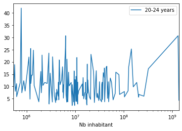

```python
dfBS.plot(x = 'Nb inhabitant',y ='20-24 years', logx = True);
plt.savefig('NB1_2_1.png')
```

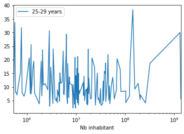

```python
dfBS.plot(x = 'Nb inhabitant',y ='25-29 years', logx = True);
plt.savefig('NB1_2_2.png')
```

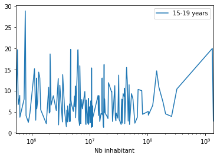

```python
dfBS.plot(x = 'Nb inhabitant',y ='15-19 years', logx = True);
plt.savefig('NB1_2_3.png')
```

## Jupyter notebook 1 :

### 1er jeu de données

#### Estimation des taux de suicide, données brutes

Estimations par pays et par tranches d’âge de 5ans jusqu’à 29ans (adolescence) et par sexe - 2016

Ce Jupyter Notebook a pour but de rendre exploitable le jeu de données, et d'en tirer un df global qui nous servira pour la suite

```python
#Crude suicide rates (per 100 000 population)
df = pd.read_csv('./Data/age_10y.csv', sep=',')

#Nombre d'habitants par pays
dfIh = pd.read_csv('./Data/inhabitants.csv', sep=',')

#Suppression des valeurs aberrantes
df = df.merge(dfIh, left_on = 'Country', right_on ='Country')
df.rename(columns={'2016': 'Nb inhabitant'}, inplace=True)
df = df[df['Nb inhabitant'] >= 5e+5]

df
```

|  | Country | Sex | 10-19 years | 20-29 years | 30-39 years | 40-49 years | 50-59 years | 60-69 years | 70-79 years | 80+ years | Nb inhabitant |
| --- | --- | --- | --- | --- | --- | --- | --- | --- | --- | --- | --- |
| 0 | Afghanistan | Both sexes | 3.1 | 10.2 | 9.2 | 6.6 | 5.6 | 5.5 | 11.0 | 42.0 | 35383128.0 |
| 1 | Afghanistan | Male | 4.8 | 16.3 | 15.1 | 10.5 | 9.3 | 9.8 | 20.9 | 70.4 | 35383128.0 |
| 2 | Afghanistan | Female | 1.2 | 3.5 | 2.7 | 2.3 | 1.6 | 1.4 | 2.3 | 20.1 | 35383128.0 |
| 3 | Albania | Both sexes | 5.0 | 6.5 | 6.1 | 9.1 | 7.8 | 6.0 | 8.3 | 16.3 | 2876101.0 |
| 4 | Albania | Male | 3.1 | 6.3 | 8.8 | 13.5 | 11.4 | 8.1 | 11.9 | 23.2 | 2876101.0 |
| ... | ... | ... | ... | ... | ... | ... | ... | ... | ... | ... | ... |
| 472 | Zambia | Male | 3.9 | 12.3 | 13.3 | 17.0 | 27.3 | 38.7 | 79.0 | 152.1 | 16363507.0 |
| 473 | Zambia | Female | 1.6 | 4.2 | 4.6 | 6.9 | 11.2 | 16.0 | 26.4 | 31.2 | 16363507.0 |
| 474 | Zimbabwe | Both sexes | 4.6 | 11.3 | 13.7 | 19.2 | 29.4 | 41.3 | 81.5 | 205.7 | 14030390.0 |
| 475 | Zimbabwe | Male | 6.4 | 19.1 | 22.8 | 30.1 | 47.0 | 62.8 | 111.5 | 285.0 | 14030390.0 |
| 476 | Zimbabwe | Female | 2.7 | 3.8 | 5.5 | 9.4 | 16.0 | 26.4 | 59.4 | 152.4 | 14030390.0 |

432 rows × 11 columns

```python
#passer les valeurs de cdc à numérique
for i in range(2,9) :
    df.iloc[:,i] = pd.to_numeric(df.iloc[:,i])
df.head(20)

#création de 3 df : Both Sexes, Male et Female
dfBS = df[df['Sex'] == 'Both sexes'].drop('Sex', axis = 1)
dfBS.index = range(0, dfBS.shape[0])
dfMale = df[df['Sex'] == 'Male'].drop('Sex', axis = 1)
dfMale.index = range(0, dfMale.shape[0])
dfFemale = df[df['Sex'] == 'Female'].drop('Sex', axis = 1)
dfFemale.index = range(0, dfFemale.shape[0])

dfBS.head(10)
```

|  | Country | 10-19 years | 20-29 years | 30-39 years | 40-49 years | 50-59 years | 60-69 years | 70-79 years | 80+ years | Nb inhabitant |
| --- | --- | --- | --- | --- | --- | --- | --- | --- | --- | --- |
| 0 | Afghanistan | 3.1 | 10.2 | 9.2 | 6.6 | 5.6 | 5.5 | 11.0 | 42.0 | 35383128.0 |
| 1 | Albania | 5.0 | 6.5 | 6.1 | 9.1 | 7.8 | 6.0 | 8.3 | 16.3 | 2876101.0 |
| 2 | Algeria | 1.3 | 4.2 | 5.3 | 4.7 | 4.1 | 4.2 | 5.6 | 9.4 | 40551404.0 |
| 3 | Angola | 2.6 | 6.6 | 5.4 | 7.0 | 14.8 | 23.8 | 42.1 | 63.5 | 28842484.0 |
| 4 | Argentina | 8.6 | 15.3 | 10.8 | 9.8 | 9.5 | 10.0 | 11.6 | 15.8 | 43590368.0 |
| 5 | Armenia | 2.2 | 4.5 | 5.4 | 9.0 | 8.4 | 10.1 | 17.4 | 27.9 | 2936146.0 |
| 6 | Australia | 5.6 | 13.9 | 16.3 | 19.7 | 18.2 | 12.9 | 13.1 | 28.8 | 24190907.0 |
| 7 | Austria | 4.5 | 10.8 | 13.1 | 15.7 | 23.1 | 17.8 | 25.1 | 40.9 | 8736668.0 |
| 8 | Azerbaijan | 1.4 | 2.2 | 3.2 | 3.5 | 4.1 | 4.5 | 6.6 | 7.7 | 9757812.0 |
| 9 | Bahrain | 3.0 | 8.8 | 8.1 | 6.1 | 4.8 | 6.2 | 11.0 | 25.2 | 1425791.0 |

```python
dfBS.describe()
```

|  | 10-19 years | 20-29 years | 30-39 years | 40-49 years | 50-59 years | 60-69 years | 70-79 years | 80+ years | Nb inhabitant |
| --- | --- | --- | --- | --- | --- | --- | --- | --- | --- |
| count | 144.000000 | 144.000000 | 144.000000 | 144.000000 | 144.000000 | 144.000000 | 144.000000 | 144.000000 | 1.440000e+02 |
| mean | 4.134028 | 10.865278 | 11.488889 | 12.811806 | 15.409722 | 17.658333 | 26.306250 | 41.976389 | 4.652718e+07 |
| std | 2.852680 | 6.958753 | 7.999983 | 8.652357 | 9.859093 | 11.522435 | 21.108366 | 35.705777 | 1.631235e+08 |
| min | 0.700000 | 2.200000 | 2.500000 | 2.100000 | 2.300000 | 2.600000 | 2.800000 | 0.000000 | 5.311460e+05 |
| 25% | 2.175000 | 5.650000 | 6.075000 | 6.675000 | 7.575000 | 8.275000 | 9.800000 | 15.775000 | 4.131920e+06 |
| 50% | 3.400000 | 8.900000 | 9.150000 | 10.500000 | 12.750000 | 16.350000 | 19.150000 | 32.600000 | 1.044287e+07 |
| 75% | 5.300000 | 14.075000 | 14.225000 | 16.700000 | 21.700000 | 23.725000 | 36.175000 | 54.100000 | 3.074511e+07 |
| max | 18.300000 | 38.000000 | 49.700000 | 54.800000 | 48.500000 | 55.400000 | 99.100000 | 205.700000 | 1.378665e+09 |

```python
dfBS[dfBS['Country'] == 'France']
```

|  | Country | 10-19 years | 20-29 years | 30-39 years | 40-49 years | 50-59 years | 60-69 years | 70-79 years | 80+ years | Nb inhabitant |
| --- | --- | --- | --- | --- | --- | --- | --- | --- | --- | --- |
| 46 | France | 2.2 | 8.0 | 13.4 | 21.8 | 23.2 | 20.3 | 27.2 | 73.4 | 66859768.0 |

Le taux de suicide en France est plus élevé que la moyenne mondiale pour les plus de 30ans

Notre pays ne se classe donc pas parmis les "bons élèves", avec des taux jusqu'à deux fois supérieur à la moyenne mondiale, comme pour les plus de 80 ans

```python
dfMale.describe()
#le taux de suicide chez les hommes est plus élevé que celui des femmes dans le monde
```

|  | 10-19 years | 20-29 years | 30-39 years | 40-49 years | 50-59 years | 60-69 years | 70-79 years | 80+ years | Nb inhabitant |
| --- | --- | --- | --- | --- | --- | --- | --- | --- | --- |
| count | 144.000000 | 144.000000 | 144.000000 | 144.000000 | 144.000000 | 144.000000 | 144.000000 | 144.000000 | 1.440000e+02 |
| mean | 5.307639 | 16.276389 | 17.722222 | 19.688889 | 23.255556 | 25.908333 | 39.153472 | 68.353472 | 4.652718e+07 |
| std | 3.461195 | 11.271407 | 13.593908 | 14.393623 | 15.903414 | 16.183876 | 27.869614 | 54.242756 | 1.631235e+08 |
| min | 0.800000 | 2.800000 | 3.300000 | 2.700000 | 2.400000 | 3.100000 | 0.000000 | 0.000000 | 5.311460e+05 |
| 25% | 2.775000 | 8.050000 | 8.775000 | 10.375000 | 11.100000 | 12.800000 | 15.925000 | 25.325000 | 4.131920e+06 |
| 50% | 4.350000 | 12.150000 | 13.900000 | 17.100000 | 19.950000 | 23.400000 | 32.400000 | 48.350000 | 1.044287e+07 |
| 75% | 6.725000 | 20.750000 | 22.025000 | 24.475000 | 31.500000 | 35.150000 | 57.625000 | 96.500000 | 3.074511e+07 |
| max | 18.200000 | 56.500000 | 88.400000 | 86.500000 | 85.400000 | 78.500000 | 121.000000 | 285.000000 | 1.378665e+09 |

```python
dfFemale.describe()
```

|  | 10-19 years | 20-29 years | 30-39 years | 40-49 years | 50-59 years | 60-69 years | 70-79 years | 80+ years | Nb inhabitant |
| --- | --- | --- | --- | --- | --- | --- | --- | --- | --- |
| count | 144.000000 | 144.000000 | 144.000000 | 144.000000 | 144.000000 | 144.000000 | 144.000000 | 144.000000 | 1.440000e+02 |
| mean | 2.906250 | 5.202083 | 5.172917 | 6.029167 | 8.086806 | 10.603472 | 16.703472 | 25.386111 | 4.652718e+07 |
| std | 2.888565 | 4.151543 | 3.705264 | 4.756591 | 7.100894 | 10.915796 | 20.628002 | 29.931812 | 1.631235e+08 |
| min | 0.000000 | 0.900000 | 0.800000 | 0.900000 | 0.000000 | 0.000000 | 0.000000 | 0.000000 | 5.311460e+05 |
| 25% | 1.100000 | 2.600000 | 2.700000 | 2.800000 | 3.200000 | 3.975000 | 4.675000 | 7.975000 | 4.131920e+06 |
| 50% | 2.050000 | 4.200000 | 4.200000 | 5.000000 | 6.750000 | 8.150000 | 11.050000 | 17.800000 | 1.044287e+07 |
| 75% | 3.625000 | 6.600000 | 6.825000 | 7.900000 | 10.675000 | 12.925000 | 19.450000 | 29.200000 | 3.074511e+07 |
| max | 18.400000 | 33.100000 | 26.900000 | 40.700000 | 56.900000 | 69.900000 | 133.700000 | 210.400000 | 1.378665e+09 |

```python
dfBS.to_csv('Both_sexes_10y.csv')
```

```python
df = pd.read_csv('./Data/data.csv', sep=',')

#suppression des colonnes inutiles
#rendre exploitable les données
df = df.drop(0, axis = 0)
df.columns = df.iloc[0,:]
df = df.drop(1, axis = 0)
df.index = range(0, df.shape[0])
df = df.drop('5-9 years', axis = 1)

#passer les valeurs de cdc à numérique
for i in range(2,6) :
    df.iloc[:,i] = pd.to_numeric(df.iloc[:,i])
df.head(20)

#création de 3 df : Both Sexes, Male et Female
dfBS = df[df['Sex'] == 'Both sexes'].drop('Sex', axis = 1)
dfBS.index = range(0, dfBS.shape[0])
dfMale = df[df['Sex'] == 'Male'].drop('Sex', axis = 1)
dfMale.index = range(0, dfMale.shape[0])
dfFemale = df[df['Sex'] == 'Female'].drop('Sex', axis = 1)
dfFemale.index = range(0, dfFemale.shape[0])

dfBS.head(10)
```

| 1 | Country | 10-14 years | 15-19 years | 20-24 years | 25-29 years |
| --- | --- | --- | --- | --- | --- |
| 0 | Afghanistan | 0.7 | 5.8 | 10.7 | 9.5 |
| 1 | Albania | 1.5 | 7.6 | 6.6 | 6.3 |
| 2 | Algeria | 0.4 | 2.2 | 3.7 | 4.6 |
| 3 | Angola | 0.9 | 4.7 | 7.1 | 6.0 |
| 4 | Antigua and Barbuda | 0.0 | 0.0 | 0.0 | 0.0 |
| 5 | Argentina | 2.0 | 15.5 | 17.9 | 12.5 |
| 6 | Armenia | 0.5 | 3.8 | 4.8 | 4.2 |
| 7 | Australia | 1.4 | 9.8 | 13.8 | 14.0 |
| 8 | Austria | 0.8 | 7.8 | 10.7 | 10.9 |
| 9 | Azerbaijan | 0.3 | 2.4 | 2.2 | 2.2 |

```python
dfBS.describe();
```

Le plus fort taux de suicide est enregistré chez les 25-29ans, avec un taux de 1 suicide pour 10 000 hab il n'est pas possible de déduire de ces df un taux de suicide moyen chez les 10-29 ans car nous ne connaissons pas le poids des différentes catégories d'âges

```python
dfBS[dfBS['20-24 years'] >= 30]
```

| 1 | Country | 10-14 years | 15-19 years | 20-24 years | 25-29 years |
| --- | --- | --- | --- | --- | --- |
| 51 | El Salvador | 3.3 | 17.9 | 30.7 | 29.4 |
| 70 | Guyana | 7.1 | 28.9 | 42.0 | 31.8 |
| 75 | India | 2.6 | 20.0 | 30.7 | 30.0 |
| 87 | Kiribati | 2.4 | 28.9 | 39.4 | 27.2 |

```python
dfBS[dfBS['Country'] == 'France']
```

| 1 | Country | 10-14 years | 15-19 years | 20-24 years | 25-29 years |
| --- | --- | --- | --- | --- | --- |
| 59 | France | 0.8 | 3.7 | 7.1 | 8.9 |

```python
dfMale.describe()
#le taux de suicide chez les hommes est plus élevé que celui des femmes dans le monde
```

| 1 | 10-14 years | 15-19 years | 20-24 years | 25-29 years |
| --- | --- | --- | --- | --- |
| count | 183.000000 | 183.000000 | 183.000000 | 183.000000 |
| mean | 1.626230 | 9.008197 | 15.303825 | 16.098907 |
| std | 1.617783 | 6.987382 | 11.050799 | 11.506654 |
| min | 0.000000 | 0.000000 | 0.000000 | 0.000000 |
| 25% | 0.500000 | 4.550000 | 7.450000 | 8.250000 |
| 50% | 1.100000 | 6.600000 | 11.800000 | 12.400000 |
| 75% | 2.150000 | 11.750000 | 20.000000 | 20.400000 |
| max | 8.700000 | 44.000000 | 69.500000 | 66.300000 |

```python
dfFemale.describe()
```

| 1 | 10-14 years | 15-19 years | 20-24 years | 25-29 years |
| --- | --- | --- | --- | --- |
| count | 183.000000 | 183.000000 | 183.000000 | 183.000000 |
| mean | 0.928962 | 4.810383 | 5.117486 | 4.945355 |
| std | 1.109887 | 4.736908 | 4.495910 | 3.910758 |
| min | 0.000000 | 0.000000 | 0.000000 | 0.000000 |
| 25% | 0.300000 | 1.900000 | 2.300000 | 2.350000 |
| 50% | 0.600000 | 3.200000 | 3.900000 | 3.800000 |
| 75% | 1.100000 | 6.100000 | 6.800000 | 6.550000 |
| max | 7.000000 | 29.200000 | 36.100000 | 30.100000 |

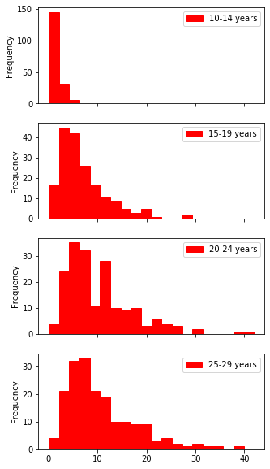

```python
dfBS.plot.hist(subplots=True, color='red', edgecolor = 'red', figsize=(5,10), bins = 20);
```

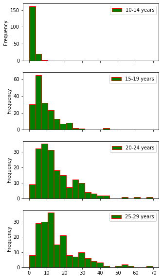

```python
dfMale.plot.hist(subplots=True, color='green', edgecolor = 'red', figsize=(5,10), bins = 20);
```

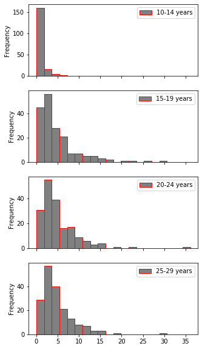

```python
dfFemale.plot.hist(subplots=True, color='grey', edgecolor = 'red', figsize=(5,10), bins = 20);
```

```python
dfBS.to_csv('Both_sexes_10-29.csv')
```